# Categorical class 1

# Overview

1. In these files, **code** is shown in *light grey boxes*
   - Mouse over the upper right corner of each box to see a clipboard icon
   - Click on the icon to copy the code and then paste it in your R
2. In R, many specialized functions are in **packages**
   - You need to **install a package** in order to use it
     - You only need to do this *once per device*
     - For example, to install the **haven** package:
       - `install.packages("haven")`
       - Or use the Rstudio GUI: **Packages** pane
   - You need to **load a package** in order to use it
     - You load or “library” a package *once per file or session*
     - For example, to load the **haven** package:
       - `library(haven)`
3. There are a number of thing about R that can cause you problems
   - R is **case-sensitive**
     - `VARIABLE` is not the same as `variable`
   - You can assign something to a name using `<-` (an arrow)
     - This is NOT the same as `=` (equal sign)
   - Students often get errors when trying to install packages in a script
     - Especially when it’s a package that’s already installed
     - It’s better to install them separately, either through the Rstudio packages pane or the console *These are the packages we’ll use today, so you can install them:
       - **haven**
       - **dplyr**
       - **ggplot2**
       - **broom**

# Data

## Read in data

- The **haven** package lets you read (and write) SPSS, SAS, and Stata files
  - Another option is the **foreign** package, but it’s older and doesn’t work quite as well
- This data file is saved as an SPSS file called `data1.sav`
- I’m reading in the file and putting it in a data frame object in R called `data1`
  - This will let us refer to it later *by name*
    - In general, it’s good to *name* everything: data, models, etc.

```r
library(haven)
data1 <- read_sav("data1.sav")
```

- There are two `X` variables and two `Y` variables
  - `y2` is just a recoded version of `y1`
    - `y2` is 1 if `y1` $\ge$ 0 and 0 if `y1` $\lt$ 0

## View data

- The `head()` function shows you the first 6 rows (by default) of a data frame
  - The `n = 10` option shows the first 10 rows instead

```r
head(data1, n = 10)
```

```
# A tibble: 10 × 4
      x1     x2       y1    y2
   <dbl>  <dbl>    <dbl> <dbl>
 1 11.2   3.12   11.7        1
 2 11.4  -3.78  -20.3        0
 3  9.78  4.11   22.6        1
 4  9.09 -4.62  -12.4        0
 5 11.2   2.71   20.9        1
 6  6.36 -0.680   0.0911     1
 7 11.3   0.442  -3.66       0
 8  9.45  9.78   49.4        1
 9  9.43 -0.240   1.80       1
10  8.16  3.61   16.0        1
```

## Create new variables

- Sometimes we want to create new variables based on existing ones, such as
  - Mean center variables
  - Create interaction terms
- There are **many** ways to do this
  - If you have a way you like, use it
  - If you don’t, I like the `mutate()` function in the **dplyr** package
    - **dplyr** is part of a group of packages called the **tidyverse**

```r
library(dplyr)
data1 <- data1 %>%
    mutate(x1c = x1 - mean(x1),
           x2c = x2 - mean(x2),
           x1cx2c = x1c * x2c)
head(data1)
```

```
# A tibble: 6 × 7
     x1     x2       y1    y2    x1c    x2c x1cx2c
  <dbl>  <dbl>    <dbl> <dbl>  <dbl>  <dbl>  <dbl>
1 11.2   3.12   11.7        1  0.681  0.893  0.608
2 11.4  -3.78  -20.3        0  0.929 -6.01  -5.58
3  9.78  4.11   22.6        1 -0.709  1.89  -1.34
4  9.09 -4.62  -12.4        0 -1.40  -6.85   9.57
5 11.2   2.71   20.9        1  0.721  0.479  0.346
6  6.36 -0.680   0.0911     1 -4.13  -2.91  12.0
```

- `data1 <- data1` means we’re adding the new variables to the existing `data1` data frame
- `%>%` symbol
  - Take the thing on the left side and do the stuff on the right side to it
  - Take `data1` and create these new variables (in the `mutate()` function) in it
- You can create several new variables with one `mutate()` statement
  - Separate them with commas
  - Here, I mean center `x1`, mean center `x2`, and create their product term

# Plots

- The best way to make plots is using the **ggplot2** package (also part of the **tidyverse**)
- You can make many exciting plots, but for now, we’re going to make some **histograms** and some **scatterplots**

## Histograms

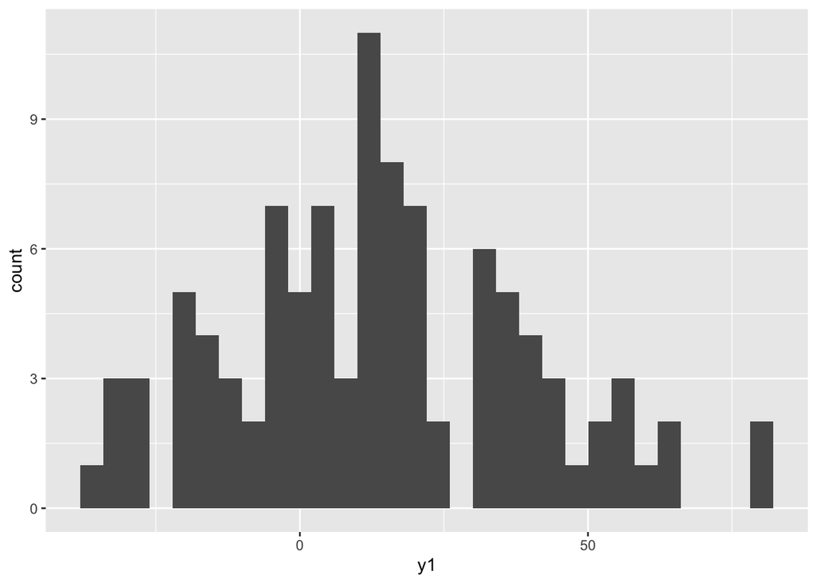

```r
library(ggplot2)

ggplot(data = data1, aes(x = y1)) +
    geom_histogram()
```

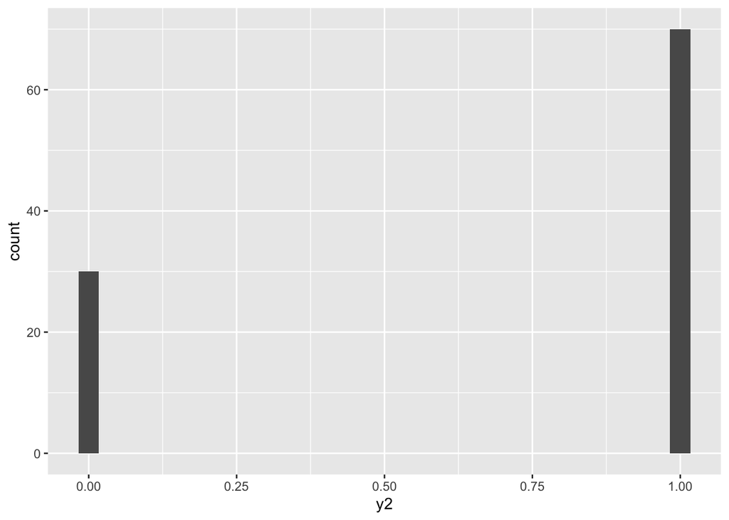

```r
ggplot(data = data1, aes(x = y2)) +
    geom_histogram()
```

- The `aes()` function is where you’ll tell **ggplot2** about which variables will be in the plot
  - Here, `y1` in the first plot and `y2` in the second
- `geom_histogram()` makes a histogram
- You can change just about every aspect of the plot
  - Colors
  - Add legend
  - Change background
- I like a little bit cleaner theme: `theme_classic()`

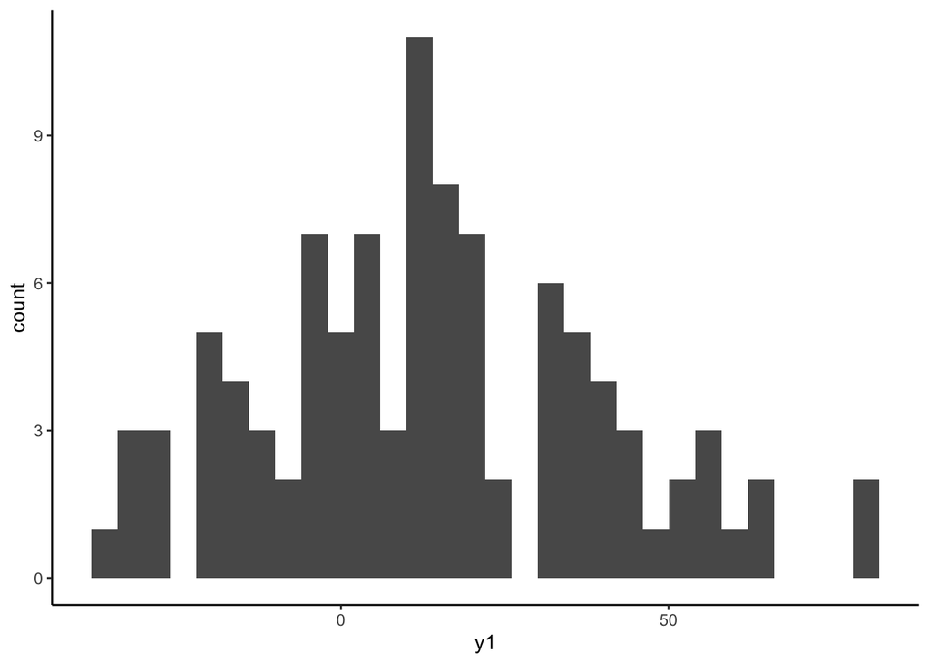

```r
ggplot(data = data1, aes(x = y1)) +
    geom_histogram() +
    theme_classic()
```

## Scatterplots

- A histogram uses only 1 variable, but a scatterplot needs 2
  - Supply both x and y in the `aes()` function
  - I’m plotting `x1` on the x axis
    - `y1` on the y axis in the first plot
    - `y2` on the y axis in the second plot
  - `geom_point()` plots the points (i.e., makes a scatterplot)

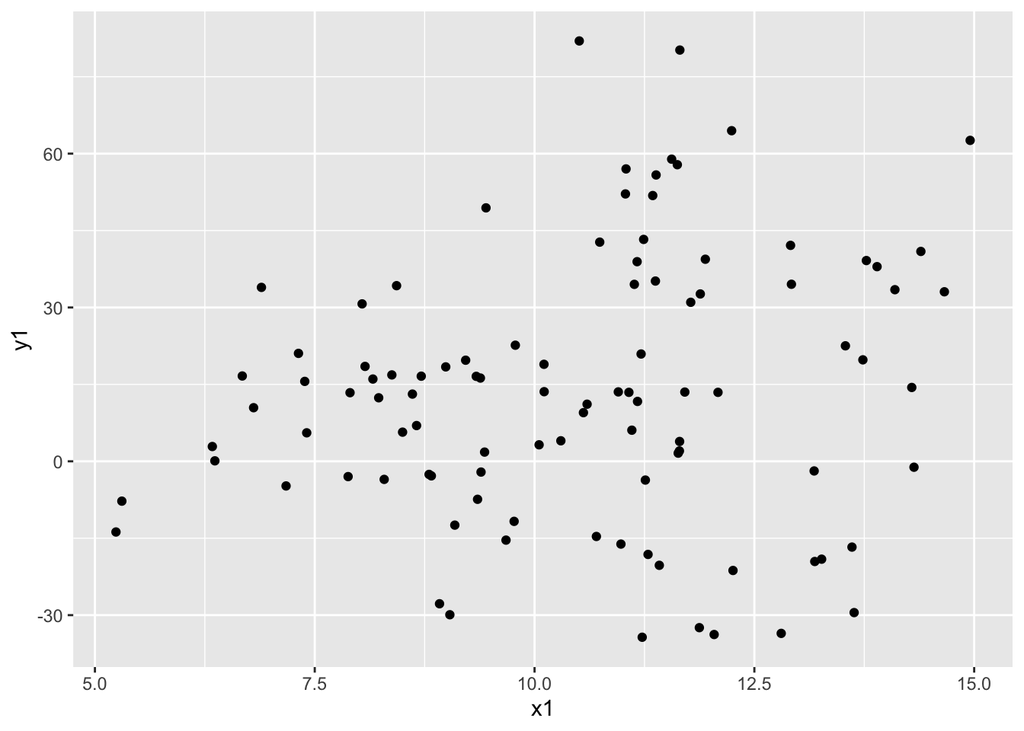

```r
ggplot(data = data1, aes(x = x1, y = y1)) +
    geom_point()
```

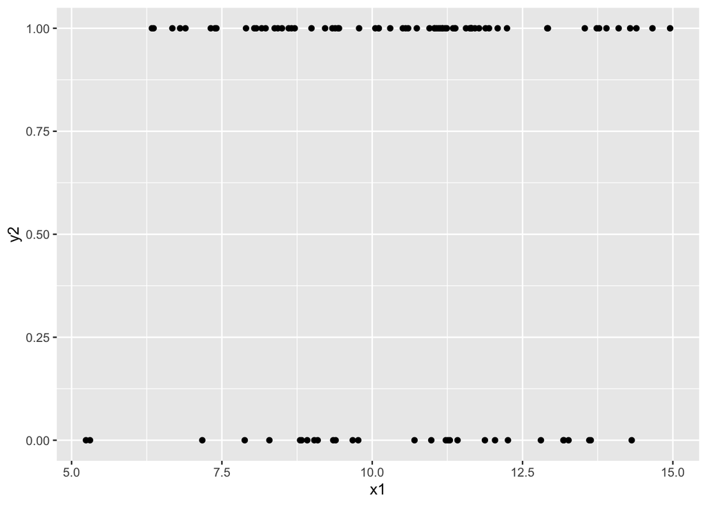

```r
ggplot(data = data1, aes(x = x1, y = y2)) +
    geom_point()
```

- We’ll see this a lot with categorical variables
  - They often take on just a few possible values
  - The points are all on top of each other and hard to see
- There are two good ways to deal with this easily
  - Reduce the `alpha` (opacity) of the points
    - Ranges from 0 (see-through) to 1 (opaque)
  - Change the point symbol to an outline-only symbol
    - All the possible options are [here](https://ggplot2.tidyverse.org/articles/ggplot2-specs.html#sec:shape-spec)
  - I’m also increasing the size of the symbols to make them easier to see
  - And changing the theme because the grey background makes it harder to see

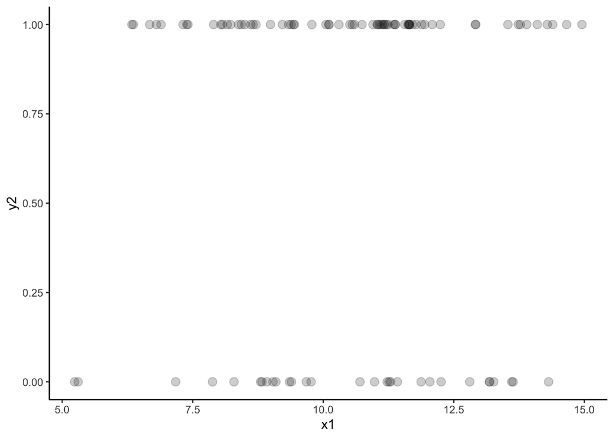

```r
ggplot(data = data1, aes(x = x1, y = y2)) +
    geom_point(alpha = 0.2, size = 3) +
    theme_classic()
```

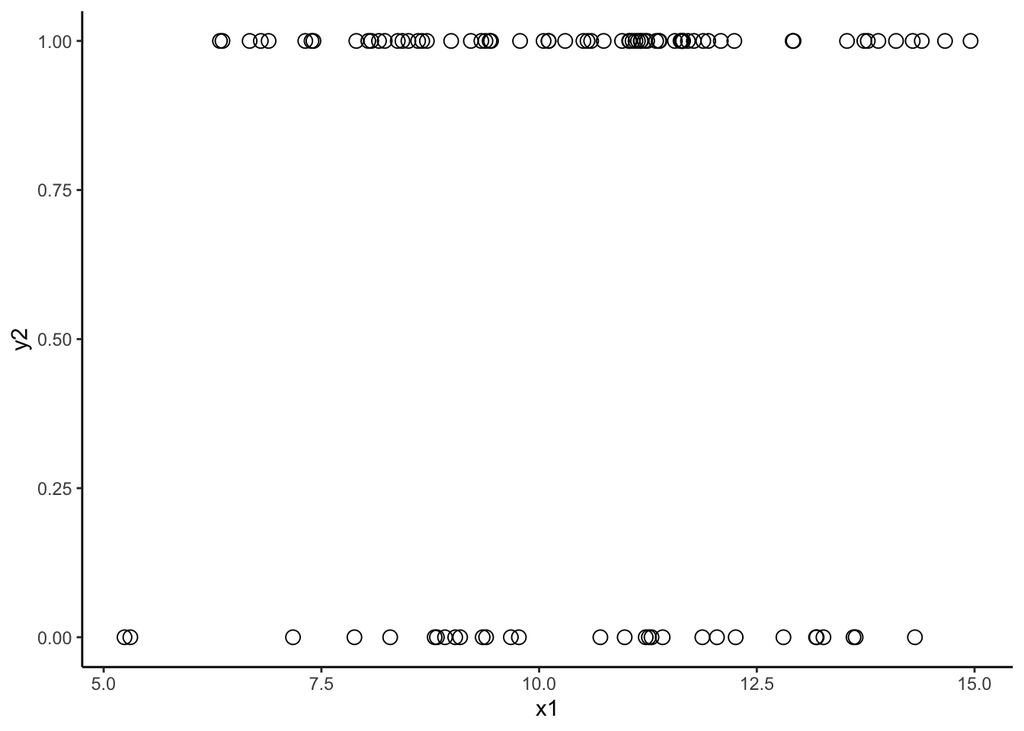

```r
ggplot(data = data1, aes(x = x1, y = y2)) +
    geom_point(shape = 1, size = 3) +
    theme_classic()
```

# Linear regression

## Some models

### Just a reminder: The **wrong way** to do an interaction

- I’m doing the wrong model here
  - I have `x1`, `x2`, and their interaction
  - **Nothing** is centered
  - Don’t do this

```r
bad_interaction <- lm(y1 ~ x1 + x2 + x1*x2, data1)
summary(bad_interaction)
```

```
Call:
lm(formula = y1 ~ x1 + x2 + x1 * x2, data = data1)

Residuals:
     Min       1Q   Median       3Q      Max
-10.9013  -3.0576   0.2947   3.3248  11.7682

Coefficients:
            Estimate Std. Error t value Pr(>|t|)
(Intercept)  1.90586    2.40873   0.791    0.431
x1           0.06637    0.22703   0.292    0.771
x2           0.13646    0.52988   0.258    0.797
x1:x2        0.44158    0.04823   9.156 9.69e-15 ***
---
Signif. codes:  0 '***' 0.001 '**' 0.01 '*' 0.05 '.' 0.1 ' ' 1

Residual standard error: 4.676 on 96 degrees of freedom
Multiple R-squared:  0.9683,    Adjusted R-squared:  0.9673
F-statistic: 978.1 on 3 and 96 DF,  p-value: < 2.2e-16
```

### Linear regression (with interaction)

- Use mean centered predictors: `x1c` and `x2c`
- Use the centered product too: `x1cx2c`

```r
model1_lr <- lm(y1 ~ x1c + x2c + x1cx2c, data1)
summary(model1_lr)
```

```
Call:
lm(formula = y1 ~ x1c + x2c + x1cx2c, data = data1)

Residuals:
     Min       1Q   Median       3Q      Max
-10.9013  -3.0576   0.2947   3.3248  11.7682

Coefficients:
            Estimate Std. Error t value Pr(>|t|)
(Intercept) 13.21832    0.47092  28.069  < 2e-16 ***
x1c          1.04941    0.21351   4.915 3.66e-06 ***
x2c          4.76882    0.09475  50.333  < 2e-16 ***
x1cx2c       0.44158    0.04823   9.156 9.69e-15 ***
---
Signif. codes:  0 '***' 0.001 '**' 0.01 '*' 0.05 '.' 0.1 ' ' 1

Residual standard error: 4.676 on 96 degrees of freedom
Multiple R-squared:  0.9683,    Adjusted R-squared:  0.9673
F-statistic: 978.1 on 3 and 96 DF,  p-value: < 2.2e-16
```

- This is just a linear regression, so it should look familiar
  - Coefficients
  - Standard errors
  - $t$-tests
  - $p$-values
  - $R^2_{multiple}$

### GLiM. (with interaction)

- This is the **exact same model**, just using the GLiM procedure
  - Remember that linear regression is a GLiM with normal residuals and identity link function
- `family = gaussian(link = "identity"))`
  - `family` is about the **random component** (i.e., distribution of residuals)
  - `link = identity` is about the **link function**

```r
model1_glim <- glm(y1 ~ x1c + x2c + x1cx2c, data1,
                   family = gaussian(link = "identity"))
summary(model1_glim)
```

```
Call:
glm(formula = y1 ~ x1c + x2c + x1cx2c, family = gaussian(link = "identity"),
    data = data1)

Deviance Residuals:
     Min        1Q    Median        3Q       Max
-10.9013   -3.0576    0.2947    3.3248   11.7682

Coefficients:
            Estimate Std. Error t value Pr(>|t|)
(Intercept) 13.21832    0.47092  28.069  < 2e-16 ***
x1c          1.04941    0.21351   4.915 3.66e-06 ***
x2c          4.76882    0.09475  50.333  < 2e-16 ***
x1cx2c       0.44158    0.04823   9.156 9.69e-15 ***
---
Signif. codes:  0 '***' 0.001 '**' 0.01 '*' 0.05 '.' 0.1 ' ' 1

(Dispersion parameter for gaussian family taken to be 21.86157)

    Null deviance: 66247.5  on 99  degrees of freedom
Residual deviance:  2098.7  on 96  degrees of freedom
AIC: 598.18

Number of Fisher Scoring iterations: 2
```

- This is *still* just a linear regression, so most things look the same – in fact, most things are exactly numerically the same
  - Coefficients
  - Standard errors
  - $t$-tests (other software packages might give you $z$ or $\chi^2$ tests here)
  - $p$-values
- But since it’s technically a GLiM, some things are a little different
  - No $R^2_{multiple}$
    - Instead there’s a **deviance**, which we’ll use later

## Residual plots

- In order to make residuals plots, we need the residuals
  - There are several ways to do this
  - I like the **broom** package and its `augment()` function
    - It adds a bunch of things, including residuals, to the model output and saves it all as a data frame, so you can use it
    - It also works for most models you might run, including `lm()`, `glm()`, `lme()`, etc.

```r
library(broom)
aug_m1lr <- augment(model1_lr)
head(aug_m1lr)
```

```
# A tibble: 6 × 10
        y1    x1c    x2c x1cx2c .fitted .resid   .hat .sigma   .cooksd .std.re…¹
     <dbl>  <dbl>  <dbl>  <dbl>   <dbl>  <dbl>  <dbl>  <dbl>     <dbl>     <dbl>
1  11.7     0.681  0.893  0.608  18.5   -6.78  0.0112   4.65 0.00602     -1.46
2 -20.3     0.929 -6.01  -5.58  -16.9   -3.36  0.0292   4.69 0.00400     -0.730
3  22.6    -0.709  1.89  -1.34   20.9    1.76  0.0140   4.70 0.000512     0.380
4 -12.4    -1.40  -6.85   9.57  -16.7    4.24  0.0413   4.68 0.00926      0.927
5  20.9     0.721  0.479  0.346  16.4    4.51  0.0111   4.68 0.00265      0.971
6   0.0911 -4.13  -2.91  12.0     0.324 -0.233 0.0558   4.70 0.0000388   -0.0512
# … with abbreviated variable name ¹.std.resid
```

- This data frame (`aug_m1lr`) includes the observations from the model (`y1`, `x1c`, `x2c`, `x1cx2c`) as well as
  - Predicted values (`.fitted`)
  - Raw residuals (`.resid`)
  - Other diagnostics
- You can plots the residuals vs the predictors (`x1c` and `x2c`) or vs the predicted value (`.fitted`)
  - In both situations, if the model is working, you should see the same thing
    - No relationship (i.e., flat line)
    - Constant variance
- Adding `geom_smooth()` (with no additional options) to your `ggplot()` creates a moving average or loess line with a confidence interval
  - Should look like a roughly flat line with equal confidence interval
    - Ignore minor deviations are left or right edges: Running average gets weird when you get to the ends

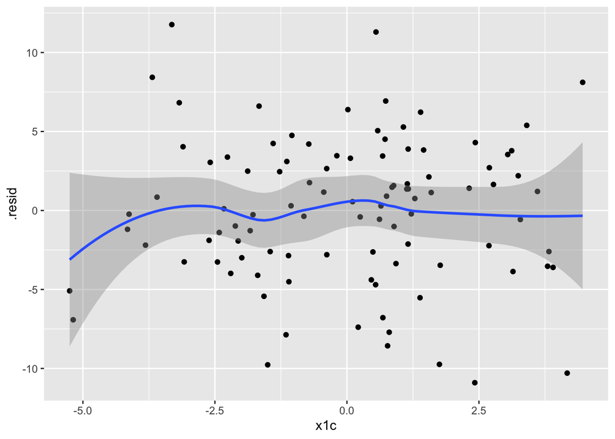

```r
ggplot(data = aug_m1lr, aes(x = x1c, y = .resid)) +
    geom_point() +
    geom_smooth()
```

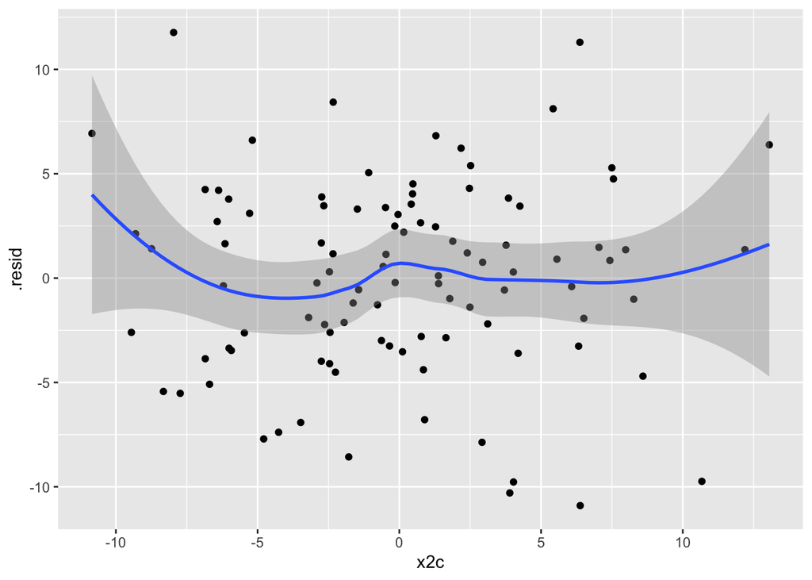

```r
ggplot(data = aug_m1lr, aes(x = x2c, y = .resid)) +
    geom_point() +
    geom_smooth()
```

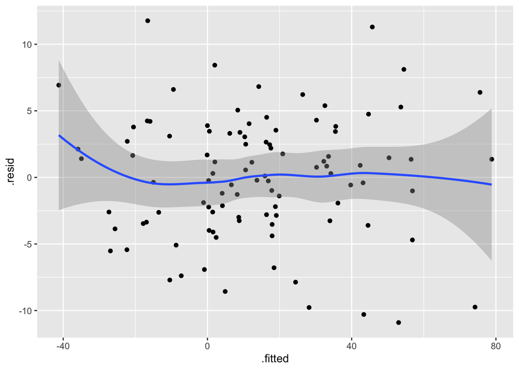

```r
ggplot(data = aug_m1lr, aes(x = .fitted, y = .resid)) +
    geom_point() +
    geom_smooth()
```

- All of these plots look pretty good
  - The line is pretty straight, pretty flat
  - The confidence interval is pretty even across the whole plot (except the ends, which will always flare a little like that)

# Class task

- Make a histogram of `y2`
  - What does the variable look like?
- Run a linear regression (`lm()` or `glm()` or both) with
  - Outcome: `y2`
  - Predictors: `x1c`, `x2c`, `x1cx2c`
  - How do the results differ from the model with `y1` as the outcome?
- Plot the residuals versus the predicted scores
  - Include the loess line with confidence interval
  - How do the residuals look? Good? Bad?
- Plot a histogram of the residuals
  - This specific plot is *not* in this handout
  - What’s going on here? Does this look like you want it to?